# Project: Analysis of loan Data from Prosper

## By Roy Muchiri

## Introduction

> This dataset contains all the propser users' loan data. The aim of this analysis is to enable Prosper determine where their strongest user Base comes from and be able to identify notable characteristics of such customers, so as to refocus their marketing efforts with knowledge on who their ideal users are.

### Dataset Description

> This data set contains information on user loan requests, and performance for 111,3066 unique users on the Prosper P2P lending platform, for usage of data collected after July 2009, to 2014.

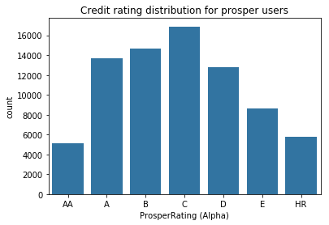

> The above infers that most prosper users have a rating of between A and C.

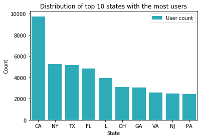

> Carlifornia has the highest number of prosper customers compared to other states

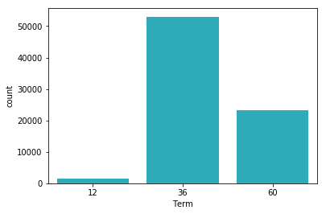

> Loans with a term of 36 months are the ost popular among prosper users.

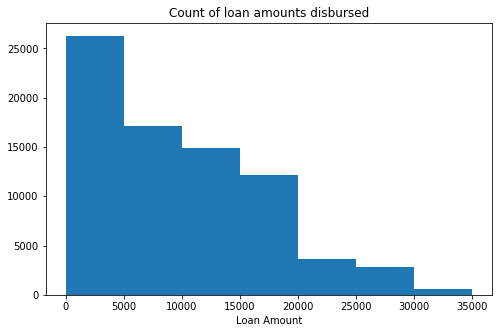

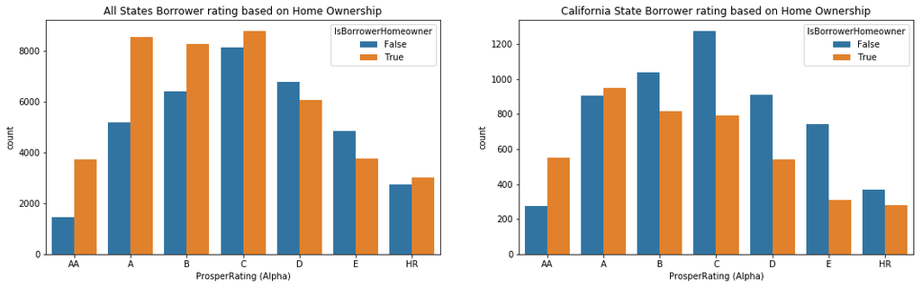

> From the data above, the highest number of California users in prosper platform are **NOT homeowners**, with majority of users with a credit rating of 'C' ,'A' and 'B', while the tottal users have a credit rating of 'C', 'B' and 'A' in descending order respectively.

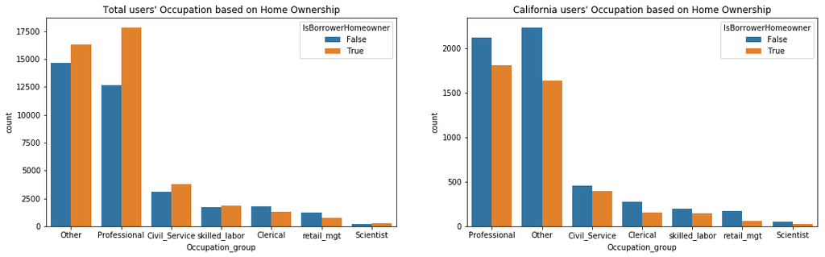

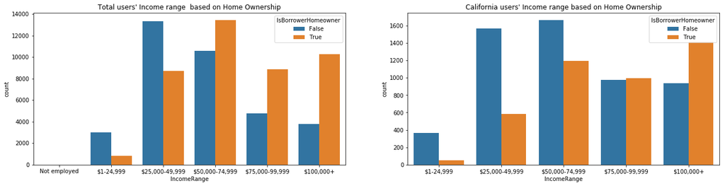

#### Conclusion

> A comparison between the total dataset and California users show that majority of carlifornia users are who are homeowners are in the income brackets of **USD 50,000-74,999 and USD 100,000+**, suggesting they are earning a higher income comparable to other states.

> It is equally interesting to note that the users in California do not have users whose Income range is listed as unemployed, however in the total dataset has one user is denoted as unemployed, denoting the user has no income.